# Lab 5: Spam Detection

**Deadline**: Monday, March 15, 5:00 PM

**Late Penalty**: There is a penalty-free grace period of one hour past the deadline. Any work that is submitted between 1 hour and 24 hours past the deadline will receive a 20% grade deduction. No other late work is accepted. Quercus submission time will be used, not your local computer time. You can submit your labs as many times as you want before the deadline, so please submit often and early.

**TA**: Gautam Dawar gautam.dawar@mail.utoronto.ca

In this assignment, we will build a recurrent neural network to classify a SMS text message as "spam" or "not spam". In the process, you will

1. Clean and process text data for machine learning.
2. Understand and implement a character-level recurrent neural network.
3. Use torchtext to build recurrent neural network models.
4. Understand batching for a recurrent neural network, and use torchtext to implement RNN batching.

### What to submit

Submit a PDF file containing all your code, outputs, and write-up. You can produce a PDF of your Google Colab file by going to File > Print and then save as PDF. The Colab instructions have more information (.html files are also acceptable).

Do not submit any other files produced by your code.

Include a link to your colab file in your submission.

## Colab Link

Include a link to your Colab file here. If you would like the TA to look at your Colab file in case your solutions are cut off, **please make sure that your Colab file is publicly accessible at the time of submission**.

Colab Link: https://colab.research.google.com/drive/1tHUckmlhwoHDR0-7pquYhDHQi36BU-Lc?usp=sharing

```python
from google.colab import drive
drive.mount('/content/drive')
```

```python
import torch
import torch.nn as nn
import torch.nn.functional as F
import torch.optim as optim
import numpy as np
```

## Part 1. Data Cleaning [15 pt]

We will be using the "SMS Spam Collection Data Set" available at http://archive.ics.uci.edu/ml/datasets/SMS+Spam+Collection

There is a link to download the "Data Folder" at the very top of the webpage. Download the zip file, unzip it, and upload the file `SMSSpamCollection` to Colab.

### Part (a) [2 pt]

Open up the file in Python, and print out one example of a spam SMS, and one example of a non-spam SMS.

What is the label value for a spam message, and what is the label value for a non-spam message?

```python
ham = False;
for line in open('/content/drive/MyDrive/Colab Notebooks/SMSSpamCollection'):
    if line.split()[0] == 'ham' and ham == False:
        ham = True
        print("non-spam example: " + line)
        print("non-spam example label: " + line.split()[0] + "\n")
    elif line.split()[0] == "spam":
        print("spam example: " +line)
        print("spam example label: " + line.split()[0])
        break
```

```
non-spam example: ham	Go until jurong point, crazy.. Available only in bugis n great world la e buffet... Cine there got amore wat...

non-spam example label: ham

spam example: spam	Free entry in 2 a wkly comp to win FA Cup final tkts 21st May 2005. Text FA to 87121 to receive entry question(std txt rate)T&C's apply 08452810075over18's

spam example label: spam
```

### Part (b) [1 pt]

How many spam messages are there in the data set? How many non-spam messages are there in the data set?

```python
cnt_spam = 0
cnt_non_spam = 0
for line in open('/content/drive/MyDrive/Colab Notebooks/SMSSpamCollection'):
    if line.split()[0] == 'ham':
        cnt_non_spam += 1
    elif line.split()[0] == 'spam':
        cnt_spam += 1

print("How many spam messages are there in the data set?")
print(cnt_spam)
print("How many non-spam messages are there in the data set?")
print(cnt_non_spam)
```

```
How many spam messages are there in the data set?
747
How many non-spam messages are there in the data set?
4827
```

### Part (c) [4 pt]

We will be using the package `torchtext` to load, process, and batch the data. A tutorial to torchtext is available below. This tutorial uses the same Sentiment140 data set that we explored during lecture.

https://medium.com/@sonicboom8/sentiment-analysis-torchtext-55fb57b1fab8

Unlike what we did during lecture, we will be building a **character level RNN**. That is, we will treat each **character** as a token in our sequence, rather than each **word**.

Identify two advantage and two disadvantage of modelling SMS text messages as a sequence of characters rather than a sequence of words.

Answer:

Advantages:

1. The miss spelled words or missing characters in words or out of vocabulary words can be taken into considered, since the it is character based, those can be more flexible to learn and compute.
2. By computing in words, it requires to storing lots of word embeddings, which takes up a lot of memory. However, by using character based, far less embeddings(characters) are needed.

Disadvantages:

1. When we want to deal with the long-distance dependency problems, character-level are not as good as word-level. More predictions characters can make, so lower in accuracy.
2. When computing with words, we can easily keep track of the meanings (relationship between characters within words). However, when using the characters, we cannot keep track of the meaning very easily, so it will make the model more complex, since it need to learn the wording of the characters (to generate word embeddings), so higher in computational time.

### Part (d) [1 pt]

We will be loading our data set using `torchtext.data.TabularDataset`. The constructor will read directly from the `SMSSpamCollection` file.

For the data file to be read successfuly, we need to specify the **fields** (columns) in the file. In our case, the dataset has two fields:

- a text field containing the sms messages,
- a label field which will be converted into a binary label.

Split the dataset into `train`, `valid`, and `test`. Use a 60-20-20 split. You may find this torchtext API page helpful: https://torchtext.readthedocs.io/en/latest/data.html#dataset

Hint: There is a `Dataset` method that can perform the random split for you.

```python
import torchtext

text_field = torchtext.legacy.data.Field(sequential=True,      # text sequence
                                  tokenize=lambda x: x, # because are building a character-RNN
                                  include_lengths=True, # to track the length of sequences, for batching
                                  batch_first=True,
                                  use_vocab=True)       # to turn each character into an integer index
label_field = torchtext.legacy.data.Field(sequential=False,    # not a sequence
                                   use_vocab=False,     # don't need to track vocabulary
                                   is_target=True,
                                   batch_first=True,
                                   preprocessing=lambda x: int(x == 'spam')) # convert text to 0 and 1

fields = [('label', label_field), ('sms', text_field)]
dataset = torchtext.legacy.data.TabularDataset("/content/drive/MyDrive/Colab Notebooks/SMSSpamCollection", # name of the file
                                        "tsv",               # fields are separated by a tab
                                        fields)


#split the dataset using 60-20-20 split, made the sample stratified and named the resulting field as label
train, valid, test = dataset.split(split_ratio=[0.6, 0.2, 0.2], stratified=True, strata_field='label')


print('the text field containing the sms messages in dataset[0]:')
print(dataset[0].sms)
print('\nthe label field (converted to a binary level) in dataset[0]:')
print(dataset[0].label) # ham -> 0

print("\nnumber of data in training:")
print(len(train))
cnt_spam = 0
cnt_non_spam = 0
for data in train:
    if data.label == 0:
        cnt_non_spam += 1
    elif  data.label == 1:
        cnt_spam += 1
print("number of non-spam data in training:")
print(cnt_non_spam)
print("number of spam data in training:")
print(cnt_spam)

print("\nnumber of data in validation:")
print(len(valid))
cnt_spam = 0
cnt_non_spam = 0
for data in valid:
    if data.label == 0:
        cnt_non_spam += 1
    elif  data.label == 1:
        cnt_spam += 1
print("number of non-spam data in validation:")
print(cnt_non_spam)
print("number of spam data in validation:")
print(cnt_spam)

print("\nnumber of data in testing:")
print(len(test))
cnt_spam = 0
cnt_non_spam = 0
for data in test:
    if data.label == 0:
        cnt_non_spam += 1
    elif  data.label == 1:
        cnt_spam += 1
print("number of non-spam data in testing:")
print(cnt_non_spam)
print("number of spam data in testing:")
print(cnt_spam)
```

```
the text field containing the sms messages in dataset[0]:
Go until jurong point, crazy.. Available only in bugis n great world la e buffet... Cine there got amore wat...

the label field (converted to a binary level) in dataset[0]:
0

number of data in training:
3343
number of non-spam data in training:
2895
number of spam data in training:
448

number of data in validation:
1115
number of non-spam data in validation:
965
number of spam data in validation:
150

number of data in testing:
1114
number of non-spam data in testing:
965
number of spam data in testing:
149
```

### Part (e) [2 pt]

You saw in part (b) that there are many more non-spam messages than spam messages. This **imbalance** in our training data will be problematic for training. We can fix this disparity by duplicating spam messages in the training set, so that the training set is roughly **balanced**.

Explain why having a balanced training set is helpful for training our neural network.

Note: if you are not sure, try removing the below code and train your mode.

```python
# save the original training examples
old_train_examples = train.examples
# get all the spam messages in `train`
train_spam = []
for item in train.examples:
    if item.label == 1:
        train_spam.append(item)
# duplicate each spam message 6 more times
train.examples = old_train_examples + train_spam * 6
```

### Part (f) [1 pt]

We need to build the vocabulary on the training data by running the below code. This finds all the possible character tokens in the training set.

Explain what the variables `text_field.vocab.stoi` and `text_field.vocab.itos` represent.

```python
text_field.build_vocab(train)
print(text_field.vocab.stoi)
print()
print(text_field.vocab.itos)
```

```
defaultdict(<bound method Vocab._default_unk_index of <torchtext.vocab.Vocab object at 0x7f9ef7ed4050>>, {'<unk>': 0, '<pad>': 1, ' ': 2, 'e': 3, 'o': 4, 't': 5, 'a': 6, 'n': 7, 'r': 8, 'i': 9, 's': 10, 'l': 11, 'u': 12, 'h': 13, '0': 14, 'd': 15, '.': 16, 'c': 17, 'm': 18, 'y': 19, 'w': 20, 'p': 21…

['<unk>', '<pad>', ' ', 'e', 'o', 't', 'a', 'n', 'r', 'i', 's', 'l', 'u', 'h', '0', 'd', '.', 'c', 'm', 'y', 'w', 'p', 'g', '1', 'f', 'b', '2', 'T', '8', 'k', 'E', 'v', '5', 'S', 'C', '4', 'I', 'O', '7', 'x', 'A', '6', '3', 'N', 'R', ',', '!', '9', 'P', 'M', 'U', 'W', 'L', 'H', 'D', 'F', 'B', 'Y', '…
```

Answer:

The variable `text_field.vocab.stoi` represents a default collection of dictionay that maps the characters with its index in the vocabulary.

The variable `text_field.vocab.itos` represents the list of characters indexed by the order in the vocabulary.

### Part (g) [2 pt]

The tokens `<unk>` and `<pad>` were not in our SMS text messages. What do these two values represent?

Answer:

The token `<unk>` represents unknown tokens.

The token `<pad>` represents the padding that is prepended to the vocabulary in addition to an `<unk>` token.

### Part (h) [2 pt]

Since text sequences are of variable length, `torchtext` provides a `BucketIterator` data loader, which batches similar length sequences together. The iterator also provides functionalities to pad sequences automatically.

Take a look at 10 batches in `train_iter`. What is the maximum length of the input sequence in each batch? How many `<pad>` tokens are used in each of the 10 batches?

```python
train_iter = torchtext.legacy.data.BucketIterator(train,
                                           batch_size=32,
                                           sort_key=lambda x: len(x.sms), # to minimize padding
                                           sort_within_batch=True,        # sort within each batch
                                           repeat=False)                  # repeat the iterator for many epochs
```

```python
cnt = 1
for batch in train_iter:
    if cnt > 10: # take a look at 10 batches in train_iter
      break

    print("Batch number: " + str(cnt))
    print("maximum length of the input sequence: " + str(int(batch.sms[1][0])))

    num = 0
    for item in batch.sms[1]:
        num += (batch.sms[1][0] - item.item())

    print("number of <pad> tokens are used: " + str(int(num)) + "\n")

    cnt += 1
```

```
Batch number: 1
maximum length of the input sequence: 145
number of <pad> tokens are used: 34

Batch number: 2
maximum length of the input sequence: 132
number of <pad> tokens are used: 53

Batch number: 3
maximum length of the input sequence: 143
number of <pad> tokens are used: 25

Batch number: 4
maximum length of the input sequence: 52
number of <pad> tokens are used: 28

Batch number: 5
maximum length of the input sequence: 143
number of <pad> tokens are used: 0

Batch number: 6
maximum length of the input sequence: 45
number of <pad> tokens are used: 25

Batch number: 7
maximum length of the input sequence: 101
number of <pad> tokens are used: 40

Batch number: 8
maximum length of the input sequence: 138
number of <pad> tokens are used: 18

Batch number: 9
maximum length of the input sequence: 150
number of <pad> tokens are used: 23

Batch number: 10
maximum length of the input sequence: 71
number of <pad> tokens are used: 33
```

## Part 2. Model Building [8 pt]

Build a recurrent neural network model, using an architecture of your choosing. Use the one-hot embedding of each character as input to your recurrent network. Use one or more fully-connected layers to make the prediction based on your recurrent network output.

Instead of using the RNN output value for the final token, another often used strategy is to max-pool over the entire output array. That is, instead of calling something like:

```
out, _ = self.rnn(x)
self.fc(out[:, -1, :])
```

where `self.rnn` is an `nn.RNN`, `nn.GRU`, or `nn.LSTM` module, and `self.fc` is a fully-connected layer, we use:

```
out, _ = self.rnn(x)
self.fc(torch.max(out, dim=1)[0])
```

This works reasonably in practice. An even better alternative is to concatenate the max-pooling and average-pooling of the RNN outputs:

```
out, _ = self.rnn(x)
out = torch.cat([torch.max(out, dim=1)[0],
                 torch.mean(out, dim=1)], dim=1)
self.fc(out)
```

We encourage you to try out all these options. The way you pool the RNN outputs is one of the "hyperparameters" that you can choose to tune later on.

```python
# You might find this code helpful for obtaining
# PyTorch one-hot vectors.

ident = torch.eye(10)
print(ident[0]) # one-hot vector
print(ident[1]) # one-hot vector
x = torch.tensor([[1, 2], [3, 4]])
print(ident[x]) # one-hot vectors
```

```
tensor([1., 0., 0., 0., 0., 0., 0., 0., 0., 0.])
tensor([0., 1., 0., 0., 0., 0., 0., 0., 0., 0.])
tensor([[[0., 1., 0., 0., 0., 0., 0., 0., 0., 0.],
         [0., 0., 1., 0., 0., 0., 0., 0., 0., 0.]],

        [[0., 0., 0., 1., 0., 0., 0., 0., 0., 0.],
         [0., 0., 0., 0., 1., 0., 0., 0., 0., 0.]]])
```

```python
# the following code are modified from week 8 lecture notes and hints provided above for pooling
class RNN(nn.Module):
    def __init__(self, input_size, hidden_size, number_classes, pooling):
        super(RNN, self).__init__()
        self.name = "RNN"
        self.emb = torch.eye(input_size)
        self.hidden_size = hidden_size
        self.rnn = nn.LSTM(input_size, hidden_size, batch_first=True)
        self.pooling = pooling

        if pooling == 2:
            self.fc = nn.Linear(hidden_size*2, number_classes) #for the max-pooling and average-pooling
        else: # one max-pooling or no pooling
            self.fc = nn.Linear(hidden_size, number_classes)

    def forward(self, x):
        x = self.emb[x]
        h0 = torch.zeros(1, x.size(0), self.hidden_size)
        c0 = torch.zeros(1, x.size(0), self.hidden_size)
        out, _ = self.rnn(x, (h0,c0))

        if self.pooling == 2:
            out = torch.cat([torch.max(out, dim=1)[0], torch.mean(out, dim=1)], dim=1)
            out = self.fc(out)
        elif self.pooling == 1:
            out = self.fc(torch.max(out, dim=1)[0])
        else:
            out = self.fc(out[:, -1, :])

        return out
```

## Part 3. Training [16 pt]

### Part (a) [4 pt]

Complete the `get_accuracy` function, which will compute the accuracy (rate) of your model across a dataset (e.g. validation set). You may modify `torchtext.data.BucketIterator` to make your computation faster.

```python
# the following code are modified from tut 5
def get_accuracy(model, data):
    """ Compute the accuracy of the `model` across a dataset `data`

    Example usage:

    >>> model = MyRNN() # to be defined
    >>> get_accuracy(model, valid) # the variable `valid` is from above
    """

    correct, total = 0, 0
    for messages, labels in data:
        output = model(messages[0])
        pred = output.max(1, keepdim=True)[1]
        correct += pred.eq(labels.view_as(pred)).sum().item()
        total += labels.shape[0]
    return correct / total
```

### Part (b) [4 pt]

Train your model. Plot the training curve of your final model. Your training curve should have the training/validation loss and accuracy plotted periodically.

Note: Not all of your batches will have the same batch size. In particular, if your training set does not divide evenly by your batch size, there will be a batch that is smaller than the rest.

```python
import matplotlib.pyplot as plt
```

```python
# the following code are modified from tut 5
def train(model, train, valid, batch_size=32, num_epoches=5, learning_rate=1e-5):
    criterion = nn.CrossEntropyLoss()
    optimizer = torch.optim.Adam(model.parameters(), lr=learning_rate)

    train_loss, val_loss, train_acc, val_acc = [], [], [], []

    '''
    train_iter = torchtext.legacy.data.BucketIterator(train,
                                           batch_size=batch_size,
                                           sort_key=lambda x: len(x.sms),
                                           sort_within_batch=True,
                                           repeat=False)
                                           '''
    val_iter = torchtext.legacy.data.BucketIterator(valid,
                                           batch_size=batch_size,
                                           sort_key=lambda x: len(x.sms),
                                           sort_within_batch=True,
                                           repeat=False)

    # training
    for epoch in range(num_epoches):
        for messages, labels in train_iter:
            optimizer.zero_grad()
            pred = model(messages[0])
            loss = criterion(pred, labels)
            loss.backward()
            optimizer.step()
        train_loss.append(float(loss))

        avg_loss = 0
        for messages, labels in val_iter:
            pred = model(messages[0])
            loss = criterion(pred, labels)
            avg_loss += float(loss)
        val_loss.append(avg_loss/len(val_iter)) # compute the average loss

        train_acc.append(get_accuracy(model, train_iter))
        val_acc.append(get_accuracy(model, val_iter))
        print("Epoch %d; Loss %f; Train Acc %f; Val Acc %f" % (epoch+1, loss, train_acc[-1], val_acc[-1]))

        model_path = "model_{0}_bs{1}_lr{2}_epoch{3}".format(model.name, batch_size, learning_rate, epoch)
        torch.save(model.state_dict(), model_path)

    # plotting
    plt.title("Training/Validation Loss")
    plt.plot(range(num_epoches), train_loss, label="Training")
    plt.plot(range(num_epoches), val_loss, label="Validation")
    plt.xlabel("number of epoches")
    plt.ylabel("Loss")
    plt.show()

    plt.title("Training/Validation Accuracy")
    plt.plot(range(num_epoches), train_acc, label="Training")
    plt.plot(range(num_epoches), val_acc, label="Validation")
    plt.xlabel("number of epoches")
    plt.ylabel("Accuracy")
    plt.legend(loc='best')
    plt.show()

    print("Final Training Accuracy: {}".format(train_acc[-1]))
    print("Final Validation Accuracy: {}".format(val_acc[-1]))
```

```
Epoch 1; Loss 0.699377; Train Acc 0.657768; Val Acc 0.630493
Epoch 2; Loss 0.692579; Train Acc 0.661582; Val Acc 0.620628
Epoch 3; Loss 0.689856; Train Acc 0.672194; Val Acc 0.626906
Epoch 4; Loss 0.683598; Train Acc 0.660090; Val Acc 0.636771
Epoch 5; Loss 0.700108; Train Acc 0.674018; Val Acc 0.643049
```

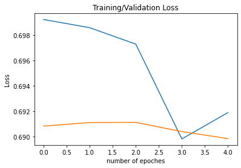

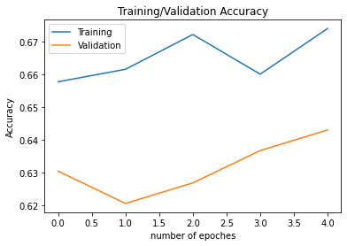

```
Final Training Accuracy: 0.6740175758580667
Final Validation Accuracy: 0.6430493273542601
```

```python
# to test if the model actually work, we use the default parameters
model = RNN(len(text_field.vocab.itos), hidden_size=50, number_classes=2, pooling=0)
train(model, train, valid, batch_size=32, num_epoches=5, learning_rate=1e-5)
```

### Part (c) [4 pt]

Choose at least 4 hyperparameters to tune. Explain how you tuned the hyperparameters. You don't need to include your training curve for every model you trained. Instead, explain what hyperparemters you tuned, what the best validation accuracy was, and the reasoning behind the hyperparameter decisions you made.

For this assignment, you should tune more than just your learning rate and epoch. Choose at least 2 hyperparameters that are unrelated to the optimizer.

```
Epoch 1; Loss 0.725868; Train Acc 0.519980; Val Acc 0.134529
Epoch 2; Loss 0.681467; Train Acc 0.519980; Val Acc 0.134529
Epoch 3; Loss 0.716782; Train Acc 0.519980; Val Acc 0.135426
Epoch 4; Loss 0.723345; Train Acc 0.519980; Val Acc 0.134529
Epoch 5; Loss 0.720428; Train Acc 0.519980; Val Acc 0.134529
Epoch 6; Loss 0.732990; Train Acc 0.519980; Val Acc 0.134529
Epoch 7; Loss 0.723105; Train Acc 0.519980; Val Acc 0.134529
Epoch 8; Loss 0.724691; Train Acc 0.519980; Val Acc 0.134529
Epoch 9; Loss 0.721463; Train Acc 0.519980; Val Acc 0.135426
Epoch 10; Loss 0.693746; Train Acc 0.519980; Val Acc 0.135426
Epoch 11; Loss 0.721138; Train Acc 0.520312; Val Acc 0.135426
Epoch 12; Loss 0.720529; Train Acc 0.519980; Val Acc 0.135426
Epoch 13; Loss 0.719454; Train Acc 0.519648; Val Acc 0.137220
Epoch 14; Loss 0.719639; Train Acc 0.520643; Val Acc 0.136323
Epoch 15; Loss 0.722488; Train Acc 0.521638; Val Acc 0.139013
Epoch 16; Loss 0.715718; Train Acc 0.522633; Val Acc 0.138117
Epoch 17; Loss 0.717246; Train Acc 0.524125; Val Acc 0.143498
Epoch 18; Loss 0.716927; Train Acc 0.525949; Val Acc 0.144395
Epoch 19; Loss 0.714388; Train Acc 0.528271; Val Acc 0.145291
Epoch 20; Loss 0.713358; Train Acc 0.533908; Val Acc 0.148879
Epoch 21; Loss 0.713178; Train Acc 0.535400; Val Acc 0.160538
Epoch 22; Loss 0.709506; Train Acc 0.546676; Val Acc 0.165022
Epoch 23; Loss 0.707101; Train Acc 0.559277; Val Acc 0.177578
Epoch 24; Loss 0.707815; Train Acc 0.568231; Val Acc 0.190135
Epoch 25; Loss 0.704891; Train Acc 0.585641; Val Acc 0.208072
Epoch 26; Loss 0.696605; Train Acc 0.606367; Val Acc 0.241256
Epoch 27; Loss 0.700514; Train Acc 0.621953; Val Acc 0.282511
Epoch 28; Loss 0.697677; Train Acc 0.666390; Val Acc 0.373991
Epoch 29; Loss 0.704842; Train Acc 0.692754; Val Acc 0.458296
Epoch 30; Loss 0.670892; Train Acc 0.729896; Val Acc 0.556054
```

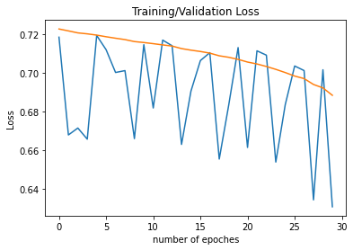

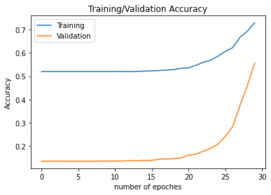

```
Final Training Accuracy: 0.7298955397114907
Final Validation Accuracy: 0.5560538116591929
```

```python
# Since the learing rate is pretty small, so it may requires more epoch iterations to train the model to a desire point.
# So in this attempt (attempt #1), we increased the num_epoches from 5 to 30 to see the trend of learning on validation accuracy.

model = RNN(len(text_field.vocab.itos), hidden_size=50, number_classes=2, pooling=0)
train(model, train, valid, batch_size=32, num_epoches=30, learning_rate=1e-5)
```

```
Epoch 1; Loss 0.732201; Train Acc 0.519980; Val Acc 0.134529
Epoch 2; Loss 0.717714; Train Acc 0.533908; Val Acc 0.146188
Epoch 3; Loss 0.695722; Train Acc 0.714475; Val Acc 0.566816
Epoch 4; Loss 0.504825; Train Acc 0.924888; Val Acc 0.947982
Epoch 5; Loss 0.328877; Train Acc 0.922401; Val Acc 0.952466
Epoch 6; Loss 0.204929; Train Acc 0.926380; Val Acc 0.951570
Epoch 7; Loss 0.311224; Train Acc 0.925883; Val Acc 0.958744
Epoch 8; Loss 0.265155; Train Acc 0.926049; Val Acc 0.957848
Epoch 9; Loss 0.216243; Train Acc 0.925883; Val Acc 0.963229
Epoch 10; Loss 0.423504; Train Acc 0.925220; Val Acc 0.965919
Epoch 11; Loss 0.088412; Train Acc 0.924391; Val Acc 0.963229
Epoch 12; Loss 0.750661; Train Acc 0.942630; Val Acc 0.947085
Epoch 13; Loss 0.159170; Train Acc 0.944122; Val Acc 0.967713
Epoch 14; Loss 0.020996; Train Acc 0.939811; Val Acc 0.967713
Epoch 15; Loss 0.179197; Train Acc 0.957718; Val Acc 0.965022
Epoch 16; Loss 0.113628; Train Acc 0.953076; Val Acc 0.973094
Epoch 17; Loss 0.037880; Train Acc 0.959542; Val Acc 0.975785
Epoch 18; Loss 0.068674; Train Acc 0.962859; Val Acc 0.973094
Epoch 19; Loss 0.089374; Train Acc 0.963853; Val Acc 0.977578
Epoch 20; Loss 0.026951; Train Acc 0.966175; Val Acc 0.974888
Epoch 21; Loss 0.155201; Train Acc 0.967170; Val Acc 0.972197
Epoch 22; Loss 0.237863; Train Acc 0.962195; Val Acc 0.975785
Epoch 23; Loss 0.064130; Train Acc 0.965346; Val Acc 0.969507
Epoch 24; Loss 0.321011; Train Acc 0.954568; Val Acc 0.956054
Epoch 25; Loss 0.207017; Train Acc 0.964682; Val Acc 0.966816
Epoch 26; Loss 0.039593; Train Acc 0.969325; Val Acc 0.973094
Epoch 27; Loss 0.303545; Train Acc 0.962693; Val Acc 0.962332
Epoch 28; Loss 0.159977; Train Acc 0.969823; Val Acc 0.979372
Epoch 29; Loss 0.025650; Train Acc 0.973139; Val Acc 0.977578
Epoch 30; Loss 0.026184; Train Acc 0.972144; Val Acc 0.973991
Epoch 31; Loss 0.276669; Train Acc 0.969159; Val Acc 0.972197
Epoch 32; Loss 0.036331; Train Acc 0.971978; Val Acc 0.973991
Epoch 33; Loss 0.027045; Train Acc 0.974299; Val Acc 0.976682
Epoch 34; Loss 0.030051; Train Acc 0.975958; Val Acc 0.975785
Epoch 35; Loss 0.279958; Train Acc 0.967501; Val Acc 0.979372
Epoch 36; Loss 0.040435; Train Acc 0.974134; Val Acc 0.973991
Epoch 37; Loss 0.028049; Train Acc 0.976123; Val Acc 0.980269
Epoch 38; Loss 0.615068; Train Acc 0.976289; Val Acc 0.979372
Epoch 39; Loss 0.019774; Train Acc 0.977781; Val Acc 0.979372
Epoch 40; Loss 0.017971; Train Acc 0.976123; Val Acc 0.978475
Epoch 41; Loss 0.630886; Train Acc 0.976455; Val Acc 0.982063
Epoch 42; Loss 0.015700; Train Acc 0.974134; Val Acc 0.979372
Epoch 43; Loss 0.014057; Train Acc 0.977450; Val Acc 0.981166
Epoch 44; Loss 0.223112; Train Acc 0.976787; Val Acc 0.980269
Epoch 45; Loss 0.041309; Train Acc 0.954900; Val Acc 0.979372
Epoch 46; Loss 0.179434; Train Acc 0.979108; Val Acc 0.979372
Epoch 47; Loss 0.015091; Train Acc 0.975958; Val Acc 0.979372
Epoch 48; Loss 0.036655; Train Acc 0.977616; Val Acc 0.977578
Epoch 49; Loss 0.151307; Train Acc 0.969988; Val Acc 0.968610
Epoch 50; Loss 0.020553; Train Acc 0.978776; Val Acc 0.980269
```

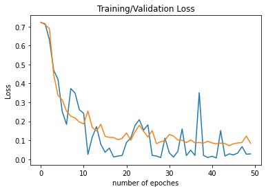

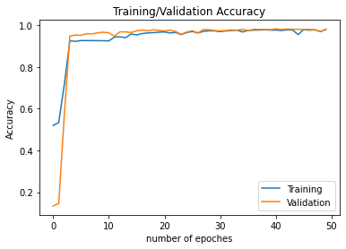

```
Final Training Accuracy: 0.9787763223346045
Final Validation Accuracy: 0.9802690582959641
```

```python
# In the previous attempt (attempt #1), we increased the number of epoches iteration from 5 to 30, and we observed that the accuracy did have a increasing trend.
# However, it happends more at epoches 20-30 with sharp increasing trends, so, there exist high possibility if we increased the epoches iteration number to 50, it may still increase.
# So, in the following attempts, we all use 50 as the epoch number.

# The second attempt (attempt #2) is used for tunning the learning rate, from 1e-5 to 1e-4.
model = RNN(len(text_field.vocab.itos), hidden_size=50, number_classes=2, pooling=0)
train(model, train, valid, batch_size=32, num_epoches=50, learning_rate=1e-4)
```